# ds4ppSet 2a

Author

Namita Karnik

Published

Invalid Date

Due to bcourses by the start of class (Thursday, Feb. 1 at 10:30am).

Name your submission files `ps2a.qmd` and `ps2a.html`.

# R for Data Science Exercises

## Debugging mindset

Look carefully! (This may seem like an exercise in pointlessness, but training your brain to notice even the tiniest difference will pay off when programming.)

1. Tweak each of the following R commands so that they run correctly:

```r
library(tidyverse)
```

```r
ggplot(data = mpg) + geom_point(mapping = aes(x = displ, y = hwy))
```

[output not shown]

```r
library(gapminder)

#| eval: false
#|
filter(mpg, cyl == 8)
```

```
# A tibble: 70 × 11
   manufacturer model      displ  year   cyl trans drv     cty   hwy fl    class
   <chr>        <chr>      <dbl> <int> <int> <chr> <chr> <int> <int> <chr> <chr>
 1 audi         a6 quattro   4.2  2008     8 auto… 4        16    23 p     mids…
 2 chevrolet    c1500 sub…   5.3  2008     8 auto… r        14    20 r     suv
 3 chevrolet    c1500 sub…   5.3  2008     8 auto… r        11    15 e     suv
 4 chevrolet    c1500 sub…   5.3  2008     8 auto… r        14    20 r     suv
 5 chevrolet    c1500 sub…   5.7  1999     8 auto… r        13    17 r     suv
 6 chevrolet    c1500 sub…   6    2008     8 auto… r        12    17 r     suv
 7 chevrolet    corvette     5.7  1999     8 manu… r        16    26 p     2sea…
 8 chevrolet    corvette     5.7  1999     8 auto… r        15    23 p     2sea…
 9 chevrolet    corvette     6.2  2008     8 manu… r        16    26 p     2sea…
10 chevrolet    corvette     6.2  2008     8 auto… r        15    25 p     2sea…
# ℹ 60 more rows
```

## grammar of graphics: `geom`s

1. What geom would you use to draw a line chart? A boxplot? A histogram? An area chart? Ans: geom_line() for a line chart geom_boxplot() for a boxplot geom_histogram() for a histogram geom_area() for an area chart
2. Will these two graphs look different? Why/why not? Ans: Both these graphs will look the same, because in the first set of code, we’ve defined the mapping argument inside of ggplot. We’ve specified it there, so when we add the ‘+’ and the two scatterplot and smooth curve arguments, we don’t need to specify how they need to be mapped.

The mapping argument, as defined by the R for data science textbook is “how variables in your dataset are mapped to visual properties (aesthetics) of your plot”.

In the second set of code, we haven’t inclided the mapping argument in the earlier ggplot brackets, but are instead clarifying it twice, once for the scatterplot and once for smooth curve.

```r
ggplot(data = mpg, mapping = aes(x = displ, y = hwy)) +
  geom_point() +
  geom_smooth()

ggplot() +
  geom_point(data = mpg, mapping = aes(x = displ, y = hwy)) +
  geom_smooth(data = mpg, mapping = aes(x = displ, y = hwy))
```

[output not shown]

3. What does the `se` argument to `geom_smooth()` do? What is the default value passed to `se`? Ans: se is the logical value. The default value assigned to se is 95% Confidence Interval (which is also the generally accepted value when you’ve run a regression and need to check the r^2 value). Adding in se = FALSE removes the confidence interval, and makes the geom_smooth curve a thin line. If we were to remove it in the graph below, the geom_smooth line created isn’t as thin (it broadens towards the end because the variation is values increases).
4. You are investigating the connection between city gas mileage and car characteristics in your role as a policy analyst for a climate change organization. Use this code to make a simple version of this graph.

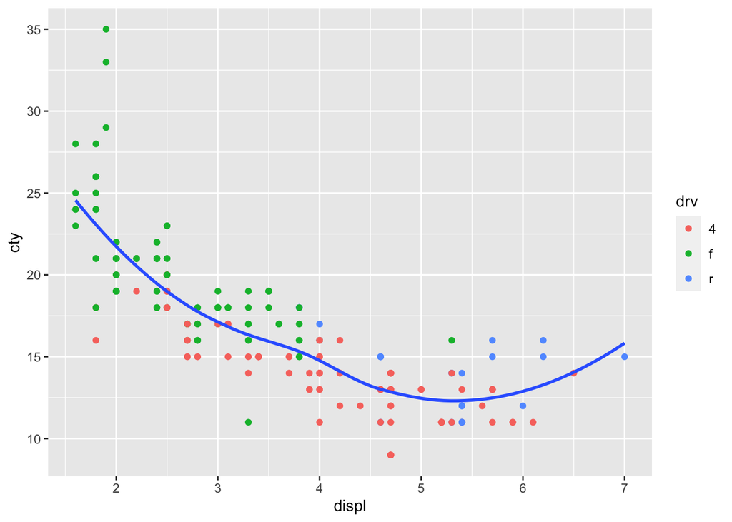

```r
?mpg

#| echo: false
#| warning: false
#| message: false
ggplot(data = mpg, mapping = aes(x = displ, y = cty)) +
    geom_point(aes(color = drv)) +
    geom_smooth(se = FALSE)
```

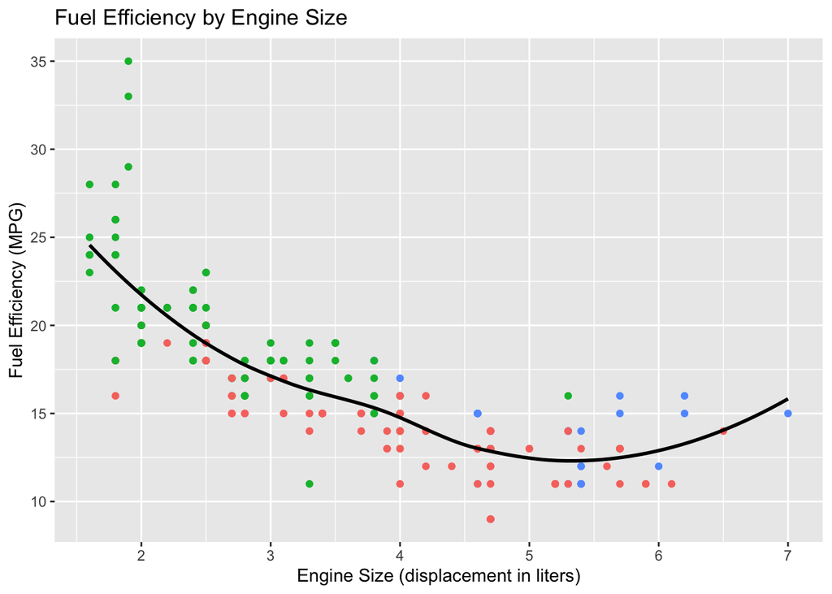

```r
#| echo: false
#| warning: false
#| message: false
ggplot(data = mpg, mapping = aes(x = displ, y = cty)) +
    geom_point(aes(color = drv)) +
    geom_smooth(color = "black", se = FALSE) +
    labs(x = "Engine Size (displacement in liters)"
       ,y = "Fuel Efficiency (MPG)"
       ,title = "Fuel Efficiency by Engine Size") +
  theme(legend.position = "none")
```

Your colleague suggests you improve the graph by:

- Making the line black
- Making the x- and y-axes labels more informative using `+ labs()`
- Using an informative title to capture the headline finding of your analysis
- Removing the legend (google might be helpful to learn how)

## grammar of graphics: Positional adjustments

5. What is the problem with this plot? How could you improve it? (*Hint:* What other `geom`s could you try?) Ans: I liked using geom_jitter. The clustering technique of sorts that geom_jitter produces is useful in understanding the density of where the data is concentrated, while still presenting individual data points (and a visible trend line). What I found interesting is that both geom_jitter(), and geom_point(position=“jitter”) gave me plots which looked the same, and after googling this, I discovered that they are indeed the same.

Geom_jitter reduces overplotting, and adds a small amount of noise to each point, which makes density of points more visible.

```r
ggplot(data = mpg, mapping = aes(x = cty, y = hwy)) +
geom_jitter()

#| eval: false
ggplot(data = mpg, mapping = aes(x = cty, y = hwy)) +
geom_point(position = "jitter")

ggplot(data = mpg, mapping = aes(x = cty, y = hwy)) +
  geom_jitter(width = 0)
ggplot(data = mpg, mapping = aes(x = cty, y = hwy)) +
  geom_jitter(width = 20)
ggplot(data = mpg, mapping = aes(x = cty, y = hwy)) +
  geom_jitter(height = 0)
```

[output not shown]

6. What parameters to `geom_jitter()` control the amount of jittering? And: From the geom_jitter() documentation, there are two arguments to jitter: width controls the amount of horizontal displacement (jitter), and height controls the amount of vertical displacement (jitter).

We can set these both parameters individually, or set both. Also, there is a default value (not zero) assigned to them, in case we don’t give it a value.

```r
ggplot(data = mpg, mapping = aes(x = cty, y = hwy)) +
  geom_jitter(width = 0)
ggplot(data = mpg, mapping = aes(x = cty, y = hwy)) +
  geom_jitter(height = 20)
ggplot(data = mpg, mapping = aes(x = cty, y = hwy)) +
  geom_jitter(width = 20,height = 0)
```

[output not shown]

7. Compare and contrast `geom_jitter()` with `geom_count()`. Ans: Both geom_jitter and geom_count are means to handle overlapping points. Geom_gitter adds a small amount of noise to each point, which makes density of points more visible. This reduces overlap and makes points visible (which otherwise would have overlapped).

Geom_count on the other hand, handles overlapping points, my making them bigger. The size of the points is propotional to the number of observations, and these are mapped at each distinct location.

```r
ggplot(data = mpg, mapping = aes(x = cty, y = hwy)) +
  geom_jitter()

ggplot(data = mpg, mapping = aes(x = cty, y = hwy)) +
  geom_count()
```

[output not shown]

# Looking ahead: data transformation

Next week’s class will focus on transforming data in the tidyverse. But you’ve already seen some of the key functions in our `gapminder` example. We’ll expand on that a bit more now. *Hint:* To do this part of the problem set, you might want to check out R4DS Ch. 3.

First, let’s load `gapminder`.

```r
library(gapminder)
gapminder
```

```
# A tibble: 1,704 × 6
   country     continent  year lifeExp      pop gdpPercap
   <fct>       <fct>     <int>   <dbl>    <int>     <dbl>
 1 Afghanistan Asia       1952    28.8  8425333      779.
 2 Afghanistan Asia       1957    30.3  9240934      821.
 3 Afghanistan Asia       1962    32.0 10267083      853.
 4 Afghanistan Asia       1967    34.0 11537966      836.
 5 Afghanistan Asia       1972    36.1 13079460      740.
 6 Afghanistan Asia       1977    38.4 14880372      786.
 7 Afghanistan Asia       1982    39.9 12881816      978.
 8 Afghanistan Asia       1987    40.8 13867957      852.
 9 Afghanistan Asia       1992    41.7 16317921      649.
10 Afghanistan Asia       1997    41.8 22227415      635.
# ℹ 1,694 more rows
```

We’ll focus on two key functions: `filter`, which chooses a subset of rows (i.e., observations); and `select`, which chooses a subset of columns (i.e., variables). Modifying the code from class, we can select the United States in 2007 via:

```r
gapminder |>
  filter(year == 2007, country == "United States")
```

```
# A tibble: 1 × 6
  country       continent  year lifeExp       pop gdpPercap
  <fct>         <fct>     <int>   <dbl>     <int>     <dbl>
1 United States Americas   2007    78.2 301139947    42952.
```

We can focus on one variable (or more if you want) by using `select`:

```r
gapminder |>
  filter(year == 2007, country == "United States") |>
  select(lifeExp)
```

```
# A tibble: 1 × 1
  lifeExp
    <dbl>
1    78.2
```

1. Output the GDP per capita of the United States in 1952.

```r
gapminder |>
  filter(year == 1952, country == "United States") |>
  select(gdpPercap)
```

```
# A tibble: 1 × 1
  gdpPercap
      <dbl>
1    13990.
```

2. Output the population of the United States in 1992, 1997, 2002, and 2007. Does your output show both year and population? Or just population? See if you can display both.

```r
gapminder |>
  select(country, pop, year) |>
  filter(country == 'United States') |>
  filter(year %in% c(1992, 1997, 2002, 2007))
```

```
# A tibble: 4 × 3
  country             pop  year
  <fct>             <int> <int>
1 United States 256894189  1992
2 United States 272911760  1997
3 United States 287675526  2002
4 United States 301139947  2007
```

3. Output a table of the life expectancy in China for all years.

```r
gapminder |>
  filter(country == "China") |>
  select(year, lifeExp)
```

```
# A tibble: 12 × 2
    year lifeExp
   <int>   <dbl>
 1  1952    44
 2  1957    50.5
 3  1962    44.5
 4  1967    58.4
 5  1972    63.1
 6  1977    64.0
 7  1982    65.5
 8  1987    67.3
 9  1992    68.7
10  1997    70.4
11  2002    72.0
12  2007    73.0
```

4. Make a plot of the life expectancy in China for all years.

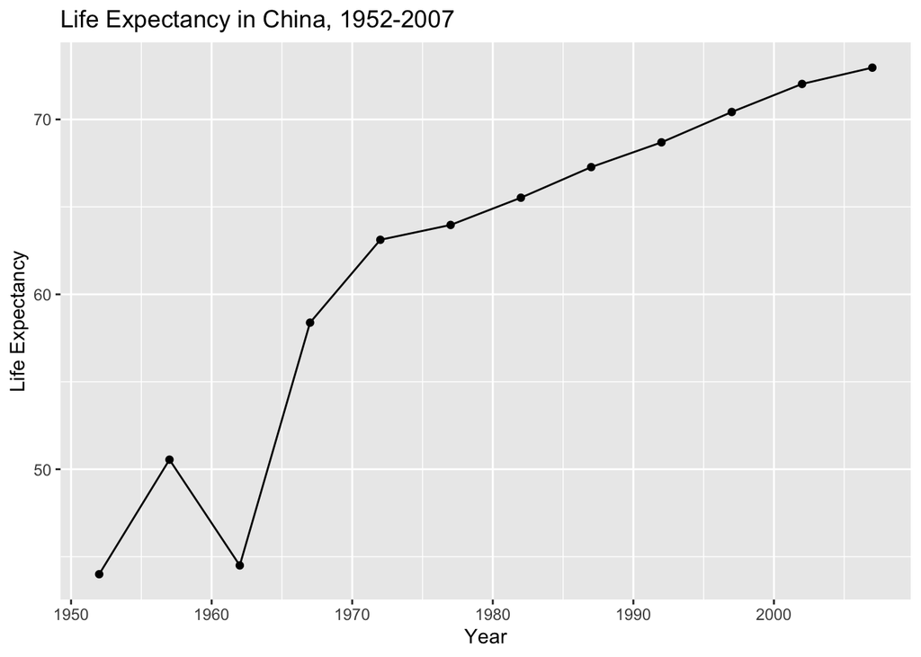

```r
gapminder |>
  filter(country == "China") |>
  ggplot(mapping = aes(x = year, y = lifeExp)) +
  geom_point() +
  geom_line() +
  labs(x = "Year"
       ,y = "Life Expectancy"
       ,title = "Life Expectancy in China, 1952-2007")
```

5. Make a plot comparing the life expectancy in China and the United States for all years.

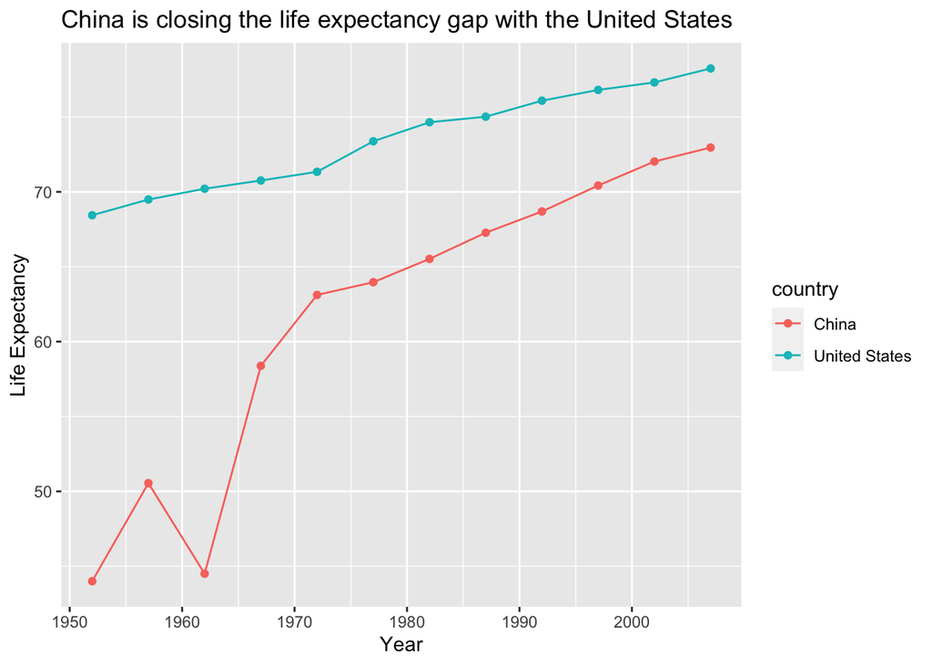

```r
gapminder |>
  filter(country %in% c("China","United States")) |>
  ggplot(mapping = aes(x = year, y = lifeExp, color = country)) +
  geom_point() +
  geom_line() +
  labs(x = "Year"
       ,y = "Life Expectancy"
       ,title = "China is closing the life expectancy gap with the United States")
```

[output not shown]